# Europe Final Energy Consumption by Product

Alejandra Enriquez-Ibanez Ertl

7/24/2020

```r
knitr::opts_chunk$set(echo = TRUE)
```

```
## * `` -> ...3
## * `` -> ...5
## * `` -> ...7
## * `` -> ...9
## * `` -> ...11
## * ...
```

[output not shown]

## Reshaping of the panel data and merging it with the coordinates database

Here I first call the world map data base, but since I only want to map Europe I need to select the names of my energy data. This can be a very tricky step because sometime the names of one database do not fully match the other f.e. United Kingdom in one and United Kingdom of the Great Britain and Northern Ireland in the other, or Czechia instead of Czech Republic. So, sometimes there might be some manual changes before trying to merge. It is also a matter of what works better for the databases you are trying to merge. In my case I also played with the ISO3 of Kosovo after merging.

```
## * `` -> ...1
```

#Function to Map

Here is the code of the function needed to later use in the server of the app. At the end you can see the map. This is just a proof that it is working and how it should look. Of course here it is not interactive yet.

```r
library(ggthemes)
```

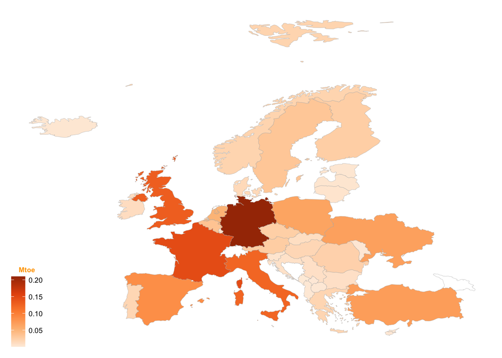

```r
prueba<- function(df, map_data, period, indicator){

  # Function for setting the aesthetics of the plot
  my_theme <- function () {
    theme_map() + theme(axis.text = element_text(size = 5),
                        axis.text.x = element_blank(),
                        axis.text.y = element_blank(),
                       axis.title = element_text(size = 5),
                       strip.text = element_text(size = 5),
                       panel.grid.major = element_blank(),
                       panel.grid.minor = element_blank(),
                       panel.background = element_blank(),
                       panel.border = element_blank(),
                       #legend.position = "bottom",
                       legend.title = element_text(face = 'bold',size=7, color = "Orange"),
                       legend.title.align = 0.5,
                       #legend.key.width = unit(3,"cm"),
                       legend.key.size = unit(0.5, "cm"),
                       strip.background = element_rect(fill = 'white', colour = 'white'))
  }

  # Select only the data that the user has selected to view
  plotdf <- df[df$Indicator == indicator & df$year == period,]
  #plotdf <- plotdf[!is.na(plotdf$ISO3), ]

  # Add the data the user wants to see to the geographical world data
  map_data['Period'] <- rep(period, nrow(map_data))
  map_data['Indicator'] <- rep(indicator, nrow(map_data))
  map_data['Value'] <- plotdf$Value[match(map_data$ISO3, plotdf$ISO3)]

  # Create caption with the data source to show underneath the map
 # capt <- paste0("Source: eurostat",
  #               sep = "\n" , "Final Energy Consumption by Product")
  # Specify the plot for the world map
  library(RColorBrewer)
  library(ggiraph)
  g <- ggplot() +
    geom_polygon_interactive(data = subset(map_data, lat >= -60 & lat <= 90), color = 'gray70', size = 0.1,
                             aes(x =long, y = lat, fill = Value, group = group,
                                 tooltip = sprintf("%s<br/>%s", region , Value))) +
    scale_fill_gradientn(colours = brewer.pal(5, "Oranges"), na.value = 'white') +
    scale_color_gradientn(colours = brewer.pal(5, "Oranges"), labels=comma) +
    labs(fill =  "Mtoe" , color = map_data$Value,
         title = NULL , x = NULL, y = NULL) +
    my_theme()

  return(g)


}
i<-"TotalBOE"
p<-"2010"
prueba(energy_melt,europe,p,i)
```

#shiny App

```r
library(shiny)
library(ggiraph)
library(shinydashboard)
```

```r
#source("helper/interactiveMAP.R")


# Define the UI
ui = dashboardPage (

    # App title

    dashboardHeader( title = tags$strong("Final Energy Consumption by Product"),
                     titleWidth = 400,
                     disable = F),

    dashboardSidebar(width = 400,
                     disable = F,
                     collapsed = F,


                     tags$head(
                         tags$style(HTML(".main-sidebar { font-size: 15px; }"))
                     ),



                     tabsetPanel(

                         tabPanel( "Product",

                                   # First input: Type of data
                                   selectInput(inputId = "Indicator",
                                               label = "Choose the fuel you want to see:",
                                               choices = list(
                                                   "Total BOE"="TotalBOE","Fossil Fuels"="FossilFuels",
                                                   "Manufactured Gases"="ManufacturedGases", "Peat & Peat Products"="Peat&PeatProducts",
                                                   "Shale Oil"="OilShale", "Natural Gas"="NaturalGas","Oil & Petroleum Products"="Oil&PetroleumProducts",
                                                   "Renewables & Biofuels"="Renewables&Biofuels", "Non-Renewable Waste"="Non-RenewableWaste",
                                                   "Electricity"="Electricity","Heat"="Heat")),


                                   selectInput(inputId = "period",
                                               label = "Choose the period for which you want to see the data:",
                                               choices = list(
                                                   "2007"="2007","2008"="2008",
                                                   "2009"="2009", "2010"="2010",
                                                   "2011"="2011", "2012"="2012","2013"="2013",
                                                   "2014"="2014","2015"="2015","2016"="2016",
                                                   "2017"="2017","2018"="2018")),

                         ),
                         tabPanel("Mtoe Converter",

                                  selectInput("unit","The unit you want to convert to:",
                                              c("Mtoe","Petajoule (PJ)","Petacalorie (Pcal)","trillion british termal units (TBtu)","terawatt-hours (TWh)","thousand tonnes of coal equivalent (ktoe)"),
                                              selected = "Mtoe"),
                                  numericInput("valor","The value you want to convert:",value=1),
                                  h5(textOutput("text1"))
                         ))

    ),

    # Main panel for displaying outputs
    dashboardBody(


        # Hide errors
        tags$style(type = "text/css",
                   ".shiny-output-error { visibility: hidden; }",
                   ".shiny-output-error:before { visibility: hidden; }"),


        box(
            title = "in Million tonnes of oil equivalent (Mtoe)",
            # Output: interactive world map
            status = "primary",height = "800px", width = "1000px",
            solidHeader = T,
            align = "left",
            column( 10 ,align="center" ,girafeOutput("distPlot", width = "125%", height="700px"))),


        h5("Source: Eurostat. Final Energy Consumption by Product."),
        tags$a(
            href="https://ec.europa.eu/eurostat/web/products-datasets/-/ten00123",
            tags$img(src="Eurostat_Newlogo.png",
                     title="Link to the data",
                     style="left",
                     width="120",
                     height="40"),

            h5("Done by: Alejandra Enriquez-Ibanez Ertl")


        ),


    )
)




# Define the server
server = function(input, output) {

    # Create the interactive world map
    output$distPlot <- renderGirafe({
        ggiraph(code = print(prueba( df= energy_melt, map_data = europe, period = input$period, indicator = input$Indicator)))
    })


    output$text1 = renderText({
        u<- input$unit;
        va<- input$valor;
        out <- 1;
        if (u=="Mtoe"){out<- round(va*1)
        }else if(u == "Petajoule (PJ"){out <- round(va*41.868)
        }else if(u == "Petacalorie (Pcal)" ){out<- round(va*10.0067)
        }else if(u == "trillion british termal units (TBtu)"){out<- round(va*39.6831)
        }else if(u == "terawatt-hours (TWh)"){ out<- round(va*11.63)
        }else if(u == "thousand tonnes of coal equivalent (ktoe)"){ out<- round(va*1428.5714)
        }
        paste(va, " ", "Mtoe"," = ",out, " ", u)
    })
}

# Finally, we can run our app by either clicking "Run App" in the top of our RStudio IDE, or by running
shinyApp(ui = ui, server = server)
```

Shiny applications not supported in static R Markdown documents